# Text Analysis on Soil Microbiome

## Model Features

Next, we use GloVe and Principal Componenet Analysis to transform the taxa counts into the corresponding taxa-property transformation space. For the GloVe algorithm, we use the function “Dtm2Tcm”, which converts a document taxa matrix into a term co-occurence matrix. In this case, each bacterial “sample”, represents a document while each “taxa” represent a term. Bacterial counts per sample are equivalent to “terms” within a “document” in the natural language analysis framework.

```r
##GloVe Algorithm
#(slow) < 3 minutes, limited by RAM
cooccur_table <- textmineR::Dtm2Tcm(t(OTU_sub)) #converts a document term matrix into a term co-occurence matrix.
#define hyperparameters for glove model
glove = GlobalVectors$new(rank = 50, x_max = 10)
#fit main glove model word vectors
#using an intel i5 and GTX1060 3GB this step took approximately 10 minutes
wv_main = glove$fit_transform(cooccur_table, n_iter = 10, convergence_tol = 0.01, n_threads = 8)
```

```
INFO  [14:13:21.152] epoch 1, loss 0.0625
INFO  [14:14:54.185] epoch 2, loss 0.0463
INFO  [14:16:26.947] epoch 3, loss 0.0365
INFO  [14:18:03.497] epoch 4, loss 0.0333
INFO  [14:19:40.682] epoch 5, loss 0.0322
INFO  [14:21:17.469] epoch 6, loss 0.0316
INFO  [14:22:53.412] epoch 7, loss 0.0314
INFO  [14:22:53.432] Success: early stopping. Improvement at iterartion 7 is less then convergence_tol
```

```r
#pull out context word vectors
wv_context = glove$components
dim(wv_context)
```

```
[1]    50 27472
```

```r
#combine main and context word vectors
word_vectors = wv_main + t(wv_context)

##PCR embeddings
pcr_embeddings <- prcomp(t(OTU_sub),rank = 50)$rotation #50 prinicipal components

#relative abundance
rf_abundance <- apply(OTU_sub, MARGIN = 2, FUN = function(x){x/sum(x)}) %>%
  as.matrix() %>%
  t()

head(word_vectors[1:10,1:10])
```

```
              [,1]        [,2]        [,3]        [,4]       [,5]       [,6]       [,7]        [,8]
1124701 0.75484835  0.70860051 -0.39440750 -1.55075723  1.0494784 -0.1574191  0.8686577  0.01076831
4479944 0.51734314  0.13721071 -0.48456077 -1.63792875  0.6144648 -0.6603320  0.8309476 -0.46412808
244336  0.08430938  0.02792918  0.09804695 -0.23772904  0.4764537  0.1023847  0.1414129 -0.32010463
185100  1.72259482  0.37296030 -0.41818770  0.05165493  0.5957698 -0.3941070  0.4595935 -0.88845201
11544   1.44707275 -0.04304437 -0.07271408 -1.10404159 -0.1646906 -0.4598083 -0.4065257 -0.42338559
511344  1.74152154  0.22022554  0.34312399 -0.54408193 -0.2519524 -0.4276274  1.0435306 -0.67876027
               [,9]      [,10]
1124701  0.07996507  0.7735243
4479944 -0.53942028  0.4751138
244336  -0.21512920  0.4161916
185100   1.17373596  0.4799430
11544    0.44200189 -0.2611142
511344  -0.01308406 -0.3493197
```

```r
#head(pcr_embeddings[1:10,1:10])
#head(rf_abundance[1:10,1:10])
```

## Further Reshaping

After creating our taxa-property space, we add a column representing the metadata feature we are trying to predict to each dataframe. This is for ease of use of the Random Forest functionm which takes in a dataframe and predicts the values within a column of interest based on the other columns within the dataframe.

```r
#custom function to add appropriate metadata to each sample based on SampleID
add_predict <- function(x, y, predict){
  res <- crossprod(x = x, y = y) %>%
    t() %>%
    as.data.frame() %>%
    tibble::rownames_to_column(var = "#SampleID") %>%
    left_join(predict, by = "#SampleID") %>%
    select(-c("#SampleID")) %>%
    mutate(feature = as.factor(feature))
  return(res)
}

#subset data by taxa data of interest into train and test
predict <- select(int_data, c("#SampleID", "feature"))
rf_word <- add_predict(x = word_vectors, y = OTU_sub, predict = predict)
rf_pca <- add_predict(x = pcr_embeddings, y = OTU_sub, predict = predict)
head(rf_word[,(ncol(rf_word)-2):ncol(rf_word)])
```

|  | V49 | V50 | feature |
| --- | --- | --- | --- |
| 1 | 120497.91 | 25414.70 | anthropogenic terrestrial biome |
| 2 | 244040.61 | -154362.36 | anthropogenic terrestrial biome |
| 3 | 123485.21 | -45786.11 | anthropogenic terrestrial biome |
| 4 | 96013.56 | -34980.74 | anthropogenic terrestrial biome |
| 5 | 32540.72 | -51502.95 | forest biome |
| 6 | -53869.82 | 212939.60 | desert biome |

## Train Models

Before we run our models. We first subset each space into a training and test set.

```r
#Define training samples
train_holdout <- 0.80
n = nrow(rf_word) * train_holdout #n = the number of samples * our training holdout
train <- base::sample(nrow(rf_pca),n) #randomly sample n bacteria-samples
#Subset data
rf_word_train <- rf_word[train,]
rf_word_train <- mutate(rf_word_train, feature = factor(feature)) #after subsetting, we have to re-factorized the feature column to account for now missing factor levels.
rf_word_test <- rf_word[-c(train),]
#
rf_pca_train <- rf_pca[train,]
rf_pca_train <- mutate(rf_pca_train, feature = factor(feature))
rf_pca_test <- rf_pca[-c(train),]
#
rf_abundance_train <- rf_abundance[train,]
rf_abundance_test <- rf_abundance[-c(train),]

#train models
word_model <- randomForest::randomForest(feature ~ ., data = rf_word_train)
pca_model <- randomForest::randomForest(feature~., data = rf_pca_train)
#(takes several minutes)
abundance_model <- randomForest::randomForest(y = as.factor(predict$feature[train]), x = rf_abundance_train)
#check model performance on training data
pred_word_train <- predict(word_model, rf_word_train, type = "class")
pred_pca_train <- predict(pca_model, rf_pca_train, type = "class")
pred_abundance_train <- predict(abundance_model, rf_abundance_train, type = "class")
#Accuracy, or TP+FP/N
mean(pred_word_train == rf_word_train$feature)
```

```
[1] 1
```

```r
mean(pred_pca_train == rf_pca_train$feature)
```

```
[1] 1
```

```r
mean(pred_abundance_train == (predict$feature[train]))
```

```
[1] 1
```

## Model Performance

After training the models, we predict on the set aside test set. We evaluate model performance in multiple ways;

- Simple accuracy assessment: what percent of model predictions are accurate? This method is an easy way to multiclass classifiers.
- Confusion Matrix: a specific table layout that allows visualization of the performance of an algorithm in terms of True Positive, True Negative, False Positive, and False Negative. We also calculate some derivations from the confusion matrix such as sensitivity, specificity, positive predictive value, and negative predictive value. We calculate confusion matrix statistics for each predicted environment class and as an average.

## accuracy

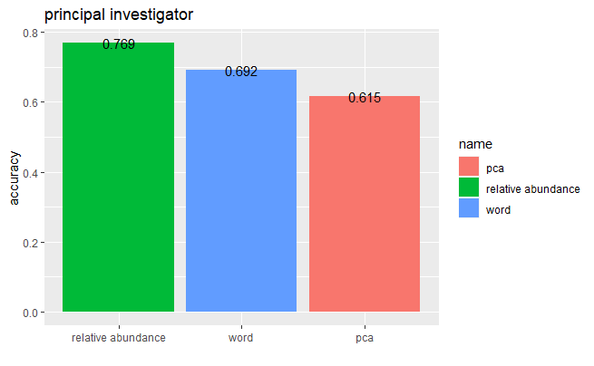

```r
#make predictions
pred_word_test <- predict(word_model, rf_word_test, type = "class")
pred_pca_test <- predict(pca_model, rf_pca_test, type = "class")
pred_abundance_test <- predict(abundance_model, rf_abundance_test, type = "class")

#accuracy
a <- mean(pred_word_test == rf_word_test$feature)
b <- mean(pred_pca_test == rf_pca_test$feature)
c <- mean(pred_abundance_test == predict$feature[-c(train)])
barplotdf <- data.frame(percent = c(a,b,c), name = c("word", "pca", "relative abundance"))
ggplot(barplotdf, aes(x = reorder(name, -percent), y = percent)) +
  geom_bar(stat = "identity", aes(fill = name)) +
  geom_text(aes(label=round(percent,3))) + labs(title = "principal investigator") +
  xlab("") + ylab("accuracy")
```

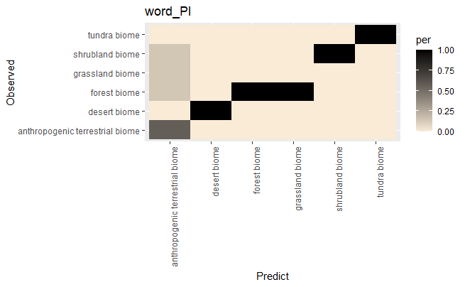

```r
#create table of predicted vs observed
res_word <- table(pred_word_test, rf_word_test$feature)
res_pca <- table(pred_pca_test, rf_pca_test$feature)
res_abundance <- table(pred_abundance_test, as.character(predict$feature[-c(train)]))

#custom heatmap function to plot positive predictions
custom_heatmap <- function(subdf, s_title = ""){
  subdf <- subdf %>% #convert table to long format
    as.data.frame()
  colnames(subdf) <- c("A", "B", "Freq") #rename columns
  subdf <- subdf %>%
    mutate(Freq = as.numeric(Freq)) %>%
    group_by(A) %>%
    mutate(countT= sum(Freq, na.rm = T)) %>%
    group_by(B, add=TRUE) %>%
    mutate(per=round(100*Freq/countT,2)/100)
  res <- ggplot(subdf, aes(x = A,y = B)) + geom_tile(aes(fill = per)) +
    theme(axis.text.x = element_text(angle = 90, hjust = 1)) +
    scale_fill_continuous(high = "black", low = "antiquewhite") +
    xlab("Predict") + ylab("Observed") +
    labs(title = s_title)

  return(res)
}
custom_heatmap(res_word, s_title = "word_PI")
```

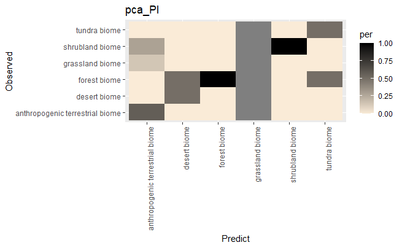

```r
custom_heatmap(res_pca, s_title = "pca_PI")
```

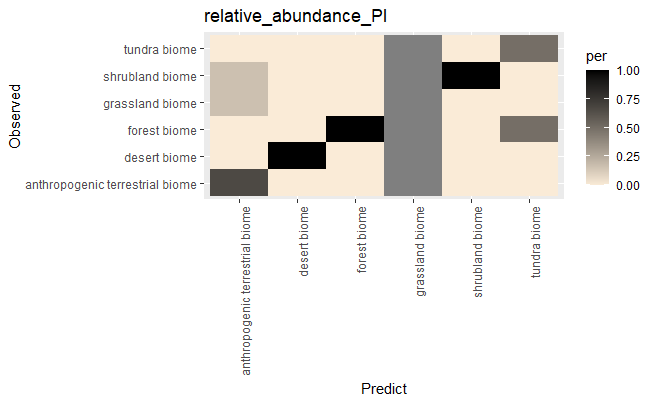

```r
custom_heatmap(res_abundance, s_title = "relative_abundance_PI")
```

## Confusion Matrix

```r
##Sensitivity and Specificity
custom_evaluate <- function(x){
  res <- list()
  temp <- x %>%
    as.data.frame() %>%
    mutate(Freq = as.numeric(Freq))
  colnames(temp) <- c("predict", "observed", "Freq")
  temp <- temp %>%
    mutate(predict = as.character(predict), observed = as.character(observed))
  categories <- unique(temp$predict)
  for(i in 1:length(categories)){
    subject = categories[i]
    TP <- filter(temp, observed == subject & predict == subject) %>%
      summarize(n = sum(Freq))
    FP <- filter(temp, observed != subject & predict == subject) %>%
      summarize(n = sum(Freq))
    TN <- filter(temp, observed != subject & predict != subject) %>%
      summarize(n = sum(Freq))
    FN <- filter(temp, observed == subject & predict != subject) %>%
      summarize(n = sum(Freq))
    PPV <- TP/(TP+FP)
    NPV <- TN/(FN+TN)
    sensitivity <- TP/(TP+FN)
    specificity <- TN/(FP+TN)
    temp_res <- as.numeric(c(TP, FP, TN, FN, PPV, NPV, sensitivity, specificity))
    names(temp_res) <- c("TP", "FP", "TN", "FN", "PPV", "NPV", "sensitivity", "specificity")
    res[[i]] <- temp_res
  }
  res <- data.frame(do.call(rbind, res))
  res <- rbind(res, (apply(res, 2, mean, na.rm = T)))
  rownames(res) <- c(categories, "average")
  return(res)
}
custom_evaluate(res_word)
```

|  | TP | FP | TN | FN | PPV | NPV | sensitivity | specificity |
| --- | --- | --- | --- | --- | --- | --- | --- | --- |
| anthropogenic terrestrial biome | 4.0 | 3.0000000 | 6.00000 | 0.0000000 | 0.5714286 | 1.0000000 | 1.0000000 | 0.6666667 |
| desert biome | 1.0 | 0.0000000 | 12.00000 | 0.0000000 | 1.0000000 | 1.0000000 | 1.0000000 | 1.0000000 |
| forest biome | 1.0 | 0.0000000 | 10.00000 | 2.0000000 | 1.0000000 | 0.8333333 | 0.3333333 | 1.0000000 |
| grassland biome | 0.0 | 1.0000000 | 11.00000 | 1.0000000 | 0.0000000 | 0.9166667 | 0.0000000 | 0.9166667 |
| shrubland biome | 2.0 | 0.0000000 | 10.00000 | 1.0000000 | 1.0000000 | 0.9090909 | 0.6666667 | 1.0000000 |
| tundra biome | 1.0 | 0.0000000 | 12.00000 | 0.0000000 | 1.0000000 | 1.0000000 | 1.0000000 | 1.0000000 |
| average | 1.5 | 0.6666667 | 10.16667 | 0.6666667 | 0.7619048 | 0.9431818 | 0.6666667 | 0.9305556 |

```r
custom_evaluate(res_pca)
```

|  | TP | FP | TN | FN | PPV | NPV | sensitivity | specificity |
| --- | --- | --- | --- | --- | --- | --- | --- | --- |
| anthropogenic terrestrial biome | 4.000000 | 3.0000000 | 6 | 0.0000000 | 0.5714286 | 1.0000000 | 1.0000000 | 0.6666667 |
| desert biome | 1.000000 | 1.0000000 | 11 | 0.0000000 | 0.5000000 | 1.0000000 | 1.0000000 | 0.9166667 |
| forest biome | 1.000000 | 0.0000000 | 10 | 2.0000000 | 1.0000000 | 0.8333333 | 0.3333333 | 1.0000000 |
| grassland biome | 0.000000 | 0.0000000 | 12 | 1.0000000 | NaN | 0.9230769 | 0.0000000 | 1.0000000 |
| shrubland biome | 1.000000 | 0.0000000 | 10 | 2.0000000 | 1.0000000 | 0.8333333 | 0.3333333 | 1.0000000 |
| tundra biome | 1.000000 | 1.0000000 | 11 | 0.0000000 | 0.5000000 | 1.0000000 | 1.0000000 | 0.9166667 |
| average | 1.333333 | 0.8333333 | 10 | 0.8333333 | 0.7142857 | 0.9316239 | 0.6111111 | 0.9166667 |

```r
custom_evaluate(res_abundance)
```

|  | TP | FP | TN | FN | PPV | NPV | sensitivity | specificity |
| --- | --- | --- | --- | --- | --- | --- | --- | --- |
| anthropogenic terrestrial biome | 4.000000 | 2.0 | 7.00000 | 0.0 | 0.6666667 | 1.0000000 | 1.0000000 | 0.7777778 |
| desert biome | 1.000000 | 0.0 | 12.00000 | 0.0 | 1.0000000 | 1.0000000 | 1.0000000 | 1.0000000 |
| forest biome | 2.000000 | 0.0 | 10.00000 | 1.0 | 1.0000000 | 0.9090909 | 0.6666667 | 1.0000000 |
| grassland biome | 0.000000 | 0.0 | 12.00000 | 1.0 | NaN | 0.9230769 | 0.0000000 | 1.0000000 |
| shrubland biome | 2.000000 | 0.0 | 10.00000 | 1.0 | 1.0000000 | 0.9090909 | 0.6666667 | 1.0000000 |
| tundra biome | 1.000000 | 1.0 | 11.00000 | 0.0 | 0.5000000 | 1.0000000 | 1.0000000 | 0.9166667 |
| average | 1.666667 | 0.5 | 10.33333 | 0.5 | 0.8333333 | 0.9568765 | 0.7222222 | 0.9490741 |

## ROC Graph

an ROC Graph is a graphical plot that illustrates the diagnostic ability of a binary classifier system as its discrimination threshold is varied. The ROC curve is created by plotting the true positive rate (TPR) against the false positive rate (FPR) at various threshold settings.

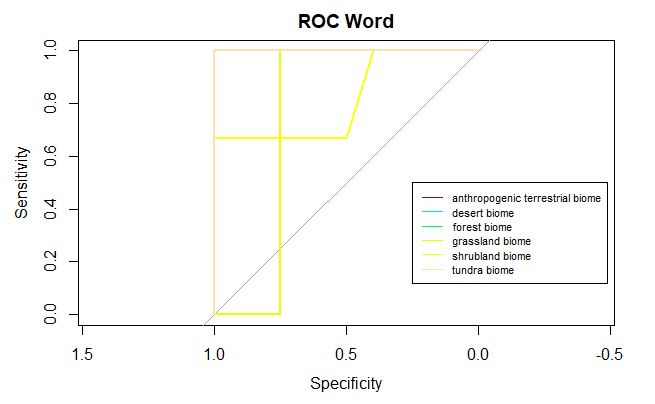

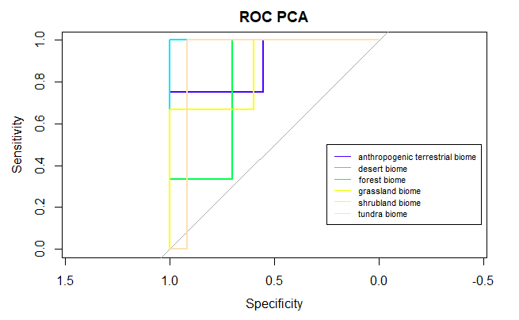

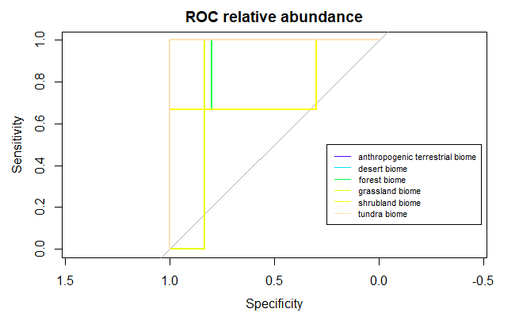

```
                   anthropogenic terrestrial biome desert biome forest biome grassland biome
word                                     1.0000000            1    1.0000000       0.7500000
pca                                      0.8888889            1    0.8000000       0.9166667
relative abundance                       1.0000000            1    0.9333333       0.8333333
average                                  0.9629630            1    0.9111111       0.8333333
                   shrubland biome tundra biome   average
word                     0.8166667    1.0000000 0.9277778
pca                      0.8666667    0.9166667 0.8981481
relative abundance       0.7666667    1.0000000 0.9222222
average                  0.8166667    0.9722222 0.9160494
```